# Linear Algebra and Gradient Descents in Artificial Neural Network (ANN) and Deep Learning

## I. Problem Statement

### 1. What is an artificial neural network (ANN) and deep learning?

An “Artificial Neural Network” (ANN) is a powerful mathematical model combining linear algebra, statistics and complex learning algorithms that attempts to mimic (or at least, is inspired by) the neural connections in our nervous system to solve a problem by taking a given number of inputs and then calculates a specified number of outputs aimed at targeting the actual result.

Deep learning belongs to the family of ANN algorithms, and in most cases, the two terms can be used interchangeably.

### 2. What is the architecture of a neural network?

For a system to be considered an ANN, it must contain a labeled, directed graph structure where each node in the graph performs some simple computation. From graph theory, we know that a directed graph consists of a set of nodes (vertices) and a set of connections (edges) that link together pairs of nodes.

[figure not shown]

Figure above depicts a simple NN that takes the weighted sum of the input x and weights w. This weighted sum is then passed through the activation function to determine if the neuron fires.

- Each node performs a simple computation.
- Each connection then carries a signal (i.e., the output of the computation) from one node to another, labeled by a weight indicating the extent to which the signal is amplified or diminished.
  > - Some connections have large, positive weights that amplify the signal, indicating that the signal is very important when making a classification.
  > - Others have negative weights, diminishing the strength of the signal, thus specifying that the output of the node is less important in the final output.

In practice, a neural network can have a complex architecture with multiple hidden layers and the outputs of the previous layers will become inputs for the next layer

[figure not shown]

Above figure shows a feedforward neural network with input layer with 3 input nodes, the 1st hidden layers with 2 nodes, the 2nd hidden layer with 3 nodes, and the output layer with 2 nodes.

### 3. What are the roles of linear algebra and gradient descent in creating and optimizing a neural network?

#### a. Linear Algebra Role

**Linear algebra** is the study of lines and planes, vector spaces and mappings that are required for linear transforms. Linear algebra enables the mathematical representation and tranformation that a neural network can perform because mathematically, a neural network is constructed from vectors and matrices.

[figure not shown]

In the above simple neural network, the values x1, x2 in the vector X are the inputs to the neural network and typically correspond to a single row (i.e., data point) in the input matrix. The input vector X is then multiplied by the weight matrix to obtain the weighted sum in the hidden or output layer. The weighted sum is then passed through an activation step (step function, RELU, Sigmoid functions, etc.) to determine output for the next layer

*Mathematic representation of input vector multiplies with the weight matrix:*

$f(∑_{i=1}^nw_ix_i) + b$

#### b. Activation Functions Role

After the input vector has been multiplied with the weight matrix to obtain the weighted sum, this weighted sum will be passed through an activation function to obtain an output. The format of the output will be dependent on the activation functions we use.

[figure not shown]

Above figure shows 6 popular activation functions used in ANN and deep learning.

1. **Step function**: The most simple activation function is the `step` function, used by the Perceptron algorithm. The function's output is binary (0 and 1). The output of step function is not differentiable which makes it difficult to train the network

[figure not shown]

1. **Sigmoid function**: `Sigmoid` function overcomes the shortcoming of step function. The output of sigmoid function is continuous from 0 to 1, differentiable and symmetric around the y-axis, which is good for learning algorithms. However, sigmoid function's output is saturated in a deep neural network and the gradient becomes so small for deep neural network training. Sigmoid function also doesn't provide negative output.

[figure not shown]

1. **tanh function (hyperbolic tangent)**: `tanh` has similar shape as sigmoid function, but provides negative output from -1 to 1. However, the output of `tanh` also saturates in the deep neural network

$f(z) = tanh(z) = (e_z − e_{−z}) / (e_z + e_{−z})$

1. **ReLU (Rectified Linear Unit)**: is a more superior function than sigmoid and tanh because the output is not saturable and also very computationally efficient. `ReLU` is the most popular activation function in deep learning as it outperforms `tanh` and `sigmoid` in many applications. However, `ReLU` is still 0 for negative inputs.

$f(x) = max(0, x)$

1. **Leaky ReLU and ELU (exponential linear units)**: 2 variants of `ReLU` that allows negative values and perform better than the standard `ReLU`

`Leaky ReLU`

[figure not shown]

`ELU`

[figure not shown]

#### b. Gradient Decent Role

While **linear algebra** provides a mechanism on how neural network is presented and how mathematical operations can be applied to manipulate inputs and outputs of an ANN. **Gradient Descent** empowers the learning and optimizating process of a neural network.

In machine learning, we need to define a task (classification, regression, etc.) and a model (Neural Network, etc.) that consists of an architecture and parameters. For a given architecture, the values of the parameters determine how accurately the model performs the task. But how do we find good values? By defining a loss function that evaluates how well the model perform then apply optimization algorithm that tweak the parameters to minimize this loss function.

[figure not shown]

Optimization algorithms are the engines that power neural networks and enable them to learn patterns from data. Obtaining a high accuracy classifier is dependent on finding a set of weights `W` (weight matrix) and `b`(bias vector) such that our data points are correctly classified. **Gradient Descent** is one of the very popular algorighms that enables us to improve `W` and `b` instead of randomly guess the best values to optimize our neural network. The algorithm aims to iteratively evaluate the parameters (weight and bias), compute the loss (based on a predefined loss function such as SoftMax/SVM), then take a small step in the direction that will minimize that loss.

[figure not shown]

Our goal when applying gradient descent is to navigate to the global minimum at the bottom of the loss landscape by following the slope (derivative) of the gradient. In one-dimensional functions, the slope is the instantaneous rate of change of the function at any point you might be interested in. The gradient is a generalization of slope for functions that don’t take a single number but a vector of numbers. Additionally, the gradient is just a vector of slopes (more commonly referred to as derivatives) for each dimension in the input space.

### 4. What are the difference between ANN and traditional Machine Learning? What are application of artificial neural network and deep learning in real-life?

ANN and Deep Learning are very powerful algorithms in working with unstructured data such as images, audios, medias etc.

In traditional machine learning algorithms, we need to perform feature engineering and feature extraction on the inputs before feeding them through the algorithms. Deep learning, and specifically Convolutional Neural Networks, take a different approach. Instead of hand-defining a set of rules and algorithms to extract features from the inputs, these features are instead automatically learned from the training process.

[figure not shown]

In this project, I will implement a small neural network in Python including the activation function and gradient descent algorithm based on the mathematic model and concepts introduced in the previous section.

Then I will introduce a basic application of the neural network to train and classify handwriting from MNIST data set. I will also validate the outcome of this neural network

## II. Gradient Descent Algorithm in an 1-layer neural network

Gradient Descent algorithm:

**Repeat {$W := W - \alpha*\frac{\partial J(w, b) }{\partial W(w,b)}$ } update the parameters (weights + bias) until converge**

- W: parameters (weights of each input + bias - w + b)
- $\frac{\partial J(w,b)}{\partial W}$ : the gradient indicating the direction to change the slope (partial derivative = height/width ) of W (weight + bias) to decrease the slope (partial derivative) of Cost function (J)
- The cost function J is defined by: $J(W, b) = -\frac{1}{m}\Sigma_{i=1}^m L(y_{pred}, y_{true}) $
- alpha: learning rate by how much to adjust W, b. Higher alpha means there's a high chance for the algorithm won't converge (it may miss the global optimum) . Lower alpha reduces this risk but it will take higher for the model to train.

```python
# Implementing a gradient descent algorithm

# import the necessary packages
import matplotlib.pyplot as plt
from sklearn.datasets import make_blobs
import numpy as np
```

```python
def sigmoid_activation(x):
# compute and return the sigmoid activation value for a  given input value
    return 1.0 / (1 + np.exp(-x))

def gradient_descent(X, y, epochs, alpha):

    # initialize our weight matrix such it has the same number of
    # columns as our input features
    print("[INFO] starting training...")
    W = np.random.uniform(size=(X.shape[1],))
    print('Initial W shape', W.shape)
    print(W)
    # initialize a list to store the loss value for each epoch
    lossHistory = []

    # loop over the desired number of epochs
    for epoch in np.arange(0, epochs):
        # take the dot product between our features `X` and the
        # weight matrix `W`, then pass this value through the
        # sigmoid activation function, thereby giving us our
        # predictions on the dataset
        preds = sigmoid_activation(X.dot(W))

        # now that we have our predictions, we need to determine
        # our `error`, which is the difference between our predictions
        # and the true values
        error = preds - y

        # given our `error`, we can compute the total loss value as
        # the sum of squared loss -- ideally, our loss should
        # decrease as we continue training
        loss = np.sum(error ** 2)
        lossHistory.append(loss)
        #print("[INFO] epoch #{}, loss={:.7f}".format(epoch + 1, loss))

        # the gradient update is therefore the dot product between
        # the transpose of `X` and our error, scaled by the total
        # number of data points in `X`
        gradient = X.T.dot(error) / X.shape[0]

        # in the update stage, all we need to do is nudge our weight
        # matrix in the opposite direction of the gradient (hence the
        # term "gradient descent" by taking a small step towards a
        # set of "more optimal" parameters
        W += -alpha * gradient


    print(f'W after {epochs} training = {W.shape, W}')

    # to demonstrate how to use our weight matrix as a classifier,
    # let's look over a sample of 10 training records with their predictions
    for i in np.random.choice(250, 10):
        # compute the prediction by taking the dot product of the
        # current feature vector with the weight matrix W, then
        # passing it through the sigmoid activation function
        activation = sigmoid_activation(X[i].dot(W))

        # the sigmoid function is defined over the range y=[0, 1],
        # so we can use 0.5 as our threshold -- if `activation` is
        # below 0.5, it's class `0`; otherwise it's class `1`
        label = 0 if activation < 0.5 else 1

        # show our output classification
        print("activation={:.4f}; predicted_label={}, true_label={}".format(
            activation, label, y[i]))

    # compute the line of best fit by setting the sigmoid function
    # to 0 and solving for X2 in terms of X1
    Y = (-W[0] - (W[1] * X)) / W[2]

    # plot the original data along with our line of best fit
    plt.figure()
    plt.scatter(X[:, 1], X[:, 2], marker="o", c=y)
    plt.plot(X, Y, "r-")

    # construct a figure that plots the loss over time
    fig = plt.figure()
    plt.plot(np.arange(0, epochs), lossHistory)
    fig.suptitle("Training Loss")
    plt.xlabel("Epoch #")
    plt.ylabel("Loss")
    plt.show()
```

```python
# generate a 2-class classification problem with 250 data points,  where each data point is a 2D feature vector
(X, y) = make_blobs(n_samples=250, n_features=2, centers=2, cluster_std=1.05, random_state=20)
# insert a column of 1's as the first entry in the feature vector
# -- this is a little trick that allows us to treat the bias as a trainable parameter *within* the weight matrix
# rather than an entirely separate variable
X = np.c_[np.ones((X.shape[0])), X]

print(X.shape)
print(y.shape)
print(X[0])
print(y)
```

```
(250, 3)
(250,)
[1.         7.85666084 6.80673325]
[1 0 0 1 1 0 0 1 1 0 1 1 1 1 0 1 1 1 0 1 0 1 0 0 1 1 0 1 1 0 0 1 0 0 1 1 1
 1 1 1 0 1 0 1 1 1 1 1 1 1 0 1 1 0 0 1 1 1 0 1 1 1 1 1 0 0 0 0 1 0 0 0 0 0
 0 0 0 0 0 0 1 0 1 1 0 1 0 1 0 1 0 1 0 1 0 1 1 0 1 0 0 0 0 1 1 1 0 0 0 0 1
 1 0 1 1 0 1 0 0 1 1 0 0 0 0 0 0 0 1 0 1 0 1 1 1 1 1 0 0 0 0 0 0 0 1 1 0 0
 0 0 1 1 0 0 0 1 1 1 0 0 1 1 0 1 1 0 0 1 0 0 1 0 0 0 1 0 0 1 1 1 1 1 0 1 0
 1 1 0 1 0 1 1 0 1 0 0 1 1 1 1 1 1 0 1 0 0 1 0 1 1 0 0 0 0 1 0 0 0 0 0 1 1
 1 0 1 1 1 0 0 1 1 1 1 1 0 0 0 1 0 0 0 0 1 1 1 1 0 0 0 0]
```

```
[INFO] starting training...
Initial W shape (3,)
[0.66150961 0.32089277 0.19516525]
W after 100 training = ((3,), array([ 0.52208951,  1.33680401, -0.94088856]))
activation=0.9982; predicted_label=1, true_label=1
activation=0.0003; predicted_label=0, true_label=0
activation=0.0117; predicted_label=0, true_label=0
activation=0.9715; predicted_label=1, true_label=1
activation=0.9994; predicted_label=1, true_label=1
activation=0.9915; predicted_label=1, true_label=1
activation=0.9989; predicted_label=1, true_label=1
activation=0.9976; predicted_label=1, true_label=1
activation=0.1290; predicted_label=0, true_label=0
activation=0.9950; predicted_label=1, true_label=1
```

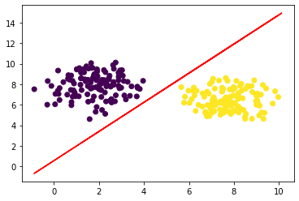

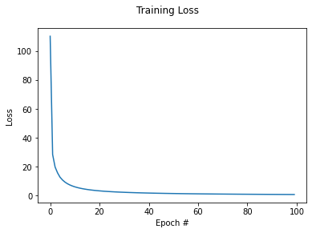

```python
epochs = 100
alpha = 0.1
gradient_descent(X, y, epochs, alpha)
```

From above example, our sample dataset has 250 records, 2 features (3 if including the bias vector).

To illustrate the role of Gradient Descent, we only have 1 layer and 1 node in this model. The sigmoid activation function was applied to the dot product of X and W to obtain the prediction with values from 0 to 1.

X is a matrix of size (250, 3), W is the vector of size (3,1) => Dot product `z` of X and W is a matrix of size (250,1) => Sigmoid activation output of `z` is matrix `a` of size (250,1)

We trained the data with 100 epochs. In each epoch, W was updated by the product of the learning rate (alpha) and the gradient of Loss function and W. After the 100th epoch, the training loss (SSE Sum Squared Error) is 0.7932436

## III. Simple Feedforward Neural Network Implementation (2-layer)

**The general methodology to build a Neural Network is to:**

1. Define the neural network structure ( # of input units, # of hidden units, etc).
2. Initialize the model's parameters
3. Iteratively,
   - Implement forward propagation
   - Compute loss
   - Implement backward propagation to get the gradients
   - Update parameters (gradient descent)

**Linear Algebra Representation of 2 Layer Neural Network (1 hidden layer, 1 output layer)**

[figure not shown]

**1. Forward Propagation**

- m: number of records in the dataset
- n: number of features in the dataset
- i : record i in the dataset
- l : layer of the neural network
- j : number of nodes in hidden layer

For i = 1 to m: (For each record i from 1 to m)

> **In the first layer, we calculate $Z^{[1]}$ and $A^{[1]}$**
> - $z^{[1](i)} = w^{[1]T} . x^{(i)} + b^{[1]}$
> - $a^{[1](i)} = \sigma(z^{[1](i)})$

> **In the 2nd layer, we calculate $Z^{[2]}$ and $A^{[2]}$**
> - $z^{[2](i)} = w^{[2]T} . a^{[1](i)} + b^{[2]}$
> - $a^{[2](i)} = \sigma(z^{[2](i)})$

In the first layer

- X : input matrix, a matrix with shape (n, m) - where m is number of observations/records, n is the number of features in the dataset. X is the stacked matrix of `m` column vectors $x^{(i)}$
- for each record i, $x^{[1](i)}$ is a vector of shape (n, 1)
- $w_j$: matrix of shape (j, n) where n in the number of features in the dataset and j is the number of units in the layer;
- for each record i, we calculate $z^{[1](i)}$ by dot product of matrix `w` (j, n) and matrix `x` (n,1) + value $b^{[1](i)}$ to get a vector of shape (j, )
- b[i] is the column vector of size (j, )
- Z[1] is the stack of `m` column vectors $z^{[1](i)}$, so Z[1] has the shape of (j, m)
- $A^{[1]}$ : output of $Z^{[1]}$ with shape (j, m) after activation function (sigmoid, tanh, relu, etc.)

Matrix `A` from the previous layers will be used as input for the next layer.

```python
# Package imports
import numpy as np
import copy
import matplotlib.pyplot as plt
from testCases_v2 import *
from public_tests import *
import sklearn
import sklearn.datasets
import sklearn.linear_model
from planar_utils import plot_decision_boundary, sigmoid, load_planar_dataset, load_extra_datasets

%matplotlib inline

%load_ext autoreload
%autoreload 2
```

```
The shape of X is: (2, 400)
The shape of Y is: (1, 400)
m = 400 training examples!
```

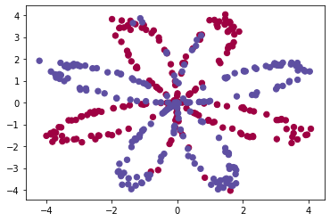

```python
X, Y = load_planar_dataset()
# Visualize the data:
plt.scatter(X[0, :], X[1, :], c=Y, s=40, cmap=plt.cm.Spectral);

shape_X = X.shape
shape_Y = Y.shape
m = X.shape[1]

print ('The shape of X is: ' + str(shape_X))
print ('The shape of Y is: ' + str(shape_Y))
print ('m = %d training examples!' % (m))
```

```python
# 1. Define Neural Network Structure
def layer_sizes(X, Y):
    """
    Arguments:
    X -- input dataset of shape (input size, number of examples)
    Y -- labels of shape (output size, number of examples)

    Returns:
    n_x -- the size of the input layer
    n_h -- the size of the hidden layer
    n_y -- the size of the output layer
    """
    n_x = X.shape[0]
    n_h = 4
    n_y = Y.shape[0]

    return (n_x, n_h, n_y)
```

```python
t_X, t_Y = layer_sizes_test_case()
(n_x, n_h, n_y) = layer_sizes(t_X, t_Y)
print("The size of the input layer is: n_x = " + str(n_x))
print("The size of the hidden layer is: n_h = " + str(n_h))
print("The size of the output layer is: n_y = " + str(n_y))
```

```
The size of the input layer is: n_x = 5
The size of the hidden layer is: n_h = 4
The size of the output layer is: n_y = 2
```

```python
# 2. Initialize network parameters
def initialize_parameters(n_x, n_h, n_y):
    """
    Argument:
    n_x -- size of the input layer
    n_h -- size of the hidden layer
    n_y -- size of the output layer

    Returns:
    params -- python dictionary containing your parameters:
                    W1 -- weight matrix of shape (n_h, n_x)
                    b1 -- bias vector of shape (n_h, 1)
                    W2 -- weight matrix of shape (n_y, n_h)
                    b2 -- bias vector of shape (n_y, 1)
    """

    W1 = np.random.randn(n_h, n_x) * 0.01
    b1 = np.zeros((n_h, 1))
    W2 = np.random.randn(n_y, n_h) * 0.01
    b2 = np.zeros((n_y, 1))

    parameters = {"W1": W1,
                  "b1": b1,
                  "W2": W2,
                  "b2": b2}

    return parameters
```

```python
np.random.seed(2)
n_x, n_h, n_y = initialize_parameters_test_case()
parameters = initialize_parameters(n_x, n_h, n_y)

print("W1 = " + str(parameters["W1"]))
print("b1 = " + str(parameters["b1"]))
print("W2 = " + str(parameters["W2"]))
print("b2 = " + str(parameters["b2"]))
```

```
W1 = [[-0.00416758 -0.00056267]
 [-0.02136196  0.01640271]
 [-0.01793436 -0.00841747]
 [ 0.00502881 -0.01245288]]
b1 = [[0.]
 [0.]
 [0.]
 [0.]]
W2 = [[-0.01057952 -0.00909008  0.00551454  0.02292208]]
b2 = [[0.]]
```

```python
def forward_propagation(X, parameters):
    """
    Argument:
    X -- input data of size (n_x, m)
    parameters -- python dictionary containing your parameters (output of initialization function)

    Returns:
    A2 -- The sigmoid output of the second activation
    cache -- a dictionary containing "Z1", "A1", "Z2" and "A2"
    """
    # Retrieve each parameter from the dictionary "parameters"
    W1 = parameters["W1"]
    b1 = parameters["b1"]
    W2 = parameters["W2"]
    b2 = parameters["b2"]

    print(W1.shape, X.shape, b1.shape)

    # Implement Forward Propagation to calculate A2 (probabilities)
    Z1 = np.matmul(W1, X) + b1
    A1 = np.tanh(Z1)
    Z2 = np.matmul(W2, A1) + b2
    A2 = sigmoid(Z2)

    assert(A2.shape == (1, X.shape[1]))

    cache = {"Z1": Z1,
             "A1": A1,
             "Z2": Z2,
             "A2": A2}

    return A2, cache
```

```python
t_X, parameters = forward_propagation_test_case()
A2, cache = forward_propagation(t_X, parameters)
print("A2 = " + str(A2))
```

```
(4, 2) (2, 3) (4, 1)
A2 = [[0.21292656 0.21274673 0.21295976]]
```

```python
def compute_cost(A2, Y):
    """
    Computes the cross-entropy cost given in equation (13)

    Arguments:
    A2 -- The sigmoid output of the second activation, of shape (1, number of examples)
    Y -- "true" labels vector of shape (1, number of examples)

    Returns:
    cost -- cross-entropy cost given equation (13)

    """

    m = Y.shape[1] # number of examples

    # Compute the cross-entropy cost
    logprobs = np.multiply(np.log(A2), Y) + (1- Y) * np.log(1 - A2)
    cost = - 1/m * np.sum(logprobs)

    #print(cost)
    cost = float(np.squeeze(cost))  # makes sure cost is the dimension we expect.
                                    # E.g., turns [[17]] into 17

    return cost
```

```python
A2, t_Y = compute_cost_test_case()
cost = compute_cost(A2, t_Y)
print("cost = " + str(compute_cost(A2, t_Y)))
```

```
cost = 0.6930587610394646
```

## IV. Applications of Neural Network

### Simple application of ANN using Keras - Classify Handwriting MNIST

```python
# import the necessary packages
from sklearn.preprocessing import LabelBinarizer
from sklearn.metrics import classification_report
from tensorflow.keras.models import Sequential
from tensorflow.keras.layers import Dense
from tensorflow.keras.optimizers import SGD
from tensorflow.keras.datasets import mnist
from tensorflow.keras import backend as K
```

```python
# Download the MNIST dataset
print("[INFO] accessing MNIST...")
((trainX, trainY), (testX, testY)) = mnist.load_data()
```

```
[INFO] accessing MNIST...
Downloading data from https://storage.googleapis.com/tensorflow/tf-keras-datasets/mnist.npz
```

```python
# Process dataset
# each image in the MNIST dataset is represented as a 28x28x1 image,
# but in order to apply a standard neural network we must first "flatten" the image to be simple list of 28x28=784 pixels
trainX = trainX.reshape((trainX.shape[0], 28 * 28 * 1))
testX = testX.reshape((testX.shape[0], 28 * 28 * 1))

# scale data to the range of [0, 1]
trainX = trainX.astype("float32") / 255.0
testX = testX.astype("float32") / 255.0

# convert the labels from integers to vectors
lb = LabelBinarizer()
trainY = lb.fit_transform(trainY)
testY = lb.transform(testY)
```

```python
print(trainX.shape)
print(trainY.shape)
print(testX.shape)
print(testY.shape)
```

```
(60000, 784)
(60000, 10)
(10000, 784)
(10000, 10)
```

```python
# Implement a simple neural network in Keras to classify MNIST images

def Feedforward(trainX, trainY, testX, testY):
    # define the 784-256-128-10 architecture using Keras
    model = Sequential()
    model.add(Dense(256, input_shape=(784,), activation="relu"))
    model.add(Dense(128, activation="relu"))
    model.add(Dense(10, activation="softmax"))

    # train the model usign SGD
    print("[INFO] training network...")
    sgd = SGD(0.01)
    model.compile(loss="categorical_crossentropy", optimizer=sgd,
        metrics=["accuracy"])
    H = model.fit(trainX, trainY, validation_data=(testX, testY),
        epochs=100, batch_size=128)

    # evaluate the network
    print("[INFO] evaluating network...")
    predictions = model.predict(testX, batch_size=128)
    print(classification_report(testY.argmax(axis=1),
        predictions.argmax(axis=1),
        target_names=[str(x) for x in lb.classes_]))

    # plot the training loss and accuracy
    plt.style.use("ggplot")
    plt.figure()
    plt.plot(np.arange(0, 100), H.history["loss"], label="train_loss")
    plt.plot(np.arange(0, 100), H.history["val_loss"], label="val_loss")
    plt.plot(np.arange(0, 100), H.history["accuracy"], label="train_acc")
    plt.plot(np.arange(0, 100), H.history["val_accuracy"], label="val_acc")
    plt.title("Training Loss and Accuracy")
    plt.xlabel("Epoch #")
    plt.ylabel("Loss/Accuracy")
    plt.legend()
```

```
[INFO] training network...
[INFO] evaluating network...
              precision    recall  f1-score   support

           0       0.98      0.98      0.98       980
           1       0.99      0.99      0.99      1135
           2       0.98      0.97      0.98      1032
           3       0.96      0.98      0.97      1010
           4       0.98      0.98      0.98       982
           5       0.98      0.97      0.98       892
           6       0.98      0.98      0.98       958
           7       0.98      0.97      0.97      1028
           8       0.97      0.97      0.97       974
           9       0.97      0.97      0.97      1009

    accuracy                           0.98     10000
   macro avg       0.98      0.98      0.98     10000
weighted avg       0.98      0.98      0.98     10000
```

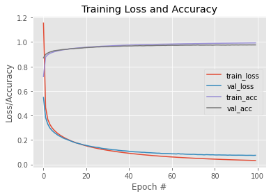

```python
Feedforward(trainX, trainY, testX, testY)
```

## Reference

[Stanford University - CS231n: Convolutional Neural Networks for Visual Recognition](https://cs231n.github.io/)

[Adrian Rosebrock, PhD - Gradient Descent with Python](https://www.pyimagesearch.com/2016/10/10/gradient-descent-with-python/?_ga=2.50450089.1649789072.1638069243-1249829026.1638069243)

[Andrew Ng - deeplearning.ai lectures](https://www.deeplearning.ai/ai-notes/optimization/)